# COVID19_Analysis

Long Bian

11/9/2020

```r
library(ggplot2)
library(lubridate)
df <- read.csv("/Users/longbian/Documents/Jobs/TDI/COVID-19_Case_Surveillance_Public_Use_Data.csv")
summary(df)
```

```
##     cdc_report_dt         pos_spec_dt            onset_dt
##  2020/06/24: 155484             :3855354             :2694659
##  2020/09/05: 117703   2020/04/06:  17952   2020/07/06:  26944
##  2020/05/26:  90948   2020/04/07:  16850   2020/07/13:  24990
##  2020/06/10:  87186   2020/03/30:  16329   2020/07/07:  23878
##  2020/07/13:  79539   2020/04/08:  15622   2020/07/01:  23813
##  2020/10/01:  75720   2020/04/03:  15465   2020/07/20:  23452
##  (Other)   :5153486   (Other)   :1822494   (Other)   :2942330
##                    current_status         sex                  age_group
##  Laboratory-confirmed case:5462778   Female :2964314   20 - 29 Years:1127849
##  Probable Case            : 297288   Male   :2728309   30 - 39 Years: 944365
##                                      Missing:  11229   40 - 49 Years: 877761
##                                      Other  :    116   50 - 59 Years: 850025
##                                      Unknown:  56083   60 - 69 Years: 595487
##                                      NA's   :     15   (Other)      :1364487
##                                                        NA's         :     92
##               Race.and.ethnicity..combined.    hosp_yn            icu_yn
##  Unknown                     :2344715       Missing:2048402   Missing:4153363
##  White, Non-Hispanic         :1583387       No     :2549669   No     : 634175
##  Hispanic/Latino             : 925883       Unknown: 717791   Unknown: 917422
##  Black, Non-Hispanic         : 583662       Yes    : 444204   Yes    :  55106
##  Multiple/Other, Non-Hispanic: 168118
##  (Other)                     : 154291
##  NA's                        :     10
##     death_yn         medcond_yn
##  Missing:2321809   Missing:3976510
##  No     :2662955   No     : 501669
##  Unknown: 617047   Unknown: 634512
##  Yes    : 158255   Yes    : 647375
##
##
##
```

```r
# replace empty with NA
df[df==""] <- NA
head(df,5)
```

|  | cdc_report_dt | pos_spec_dt | onset_dt | current_status | sex | age_group | Race.and.ethnicity..combined. | hosp_yn | icu_yn | death_yn | medcond_yn |
| --- | --- | --- | --- | --- | --- | --- | --- | --- | --- | --- | --- |
| 1 | 2020/06/30 | NA | NA | Probable Case | Other | 0 - 9 Years | Unknown | Unknown | Unknown | No | Unknown |
| 2 | 2020/06/30 | NA | NA | Probable Case | Other | 0 - 9 Years | Unknown | Unknown | Unknown | No | Unknown |
| 3 | 2020/07/05 | NA | NA | Laboratory-confirmed case | Other | 0 - 9 Years | Unknown | Missing | Missing | Missing | Missing |
| 4 | 2020/06/10 | NA | 2020/03/27 | Probable Case | Other | 0 - 9 Years | Unknown | No | Unknown | No | Unknown |
| 5 | 2020/07/13 | NA | 2020/04/20 | Probable Case | Other | 0 - 9 Years | Unknown | No | Unknown | No | Unknown |

```r
tail(df,5)
```

|  | cdc_report_dt | pos_spec_dt | onset_dt | current_status | sex | age_group | Race.and.ethnicity..combined. | hosp_yn | icu_yn | death_yn | medcond_yn |
| --- | --- | --- | --- | --- | --- | --- | --- | --- | --- | --- | --- |
| 5760062 | 2020/08/05 | 2020/06/11 | NA | Laboratory-confirmed case | Female | 70 - 79 Years | Black, Non-Hispanic | Missing | Missing | Missing | Yes |
| 5760063 | 2020/06/15 | 2020/06/11 | 2020/06/16 | Laboratory-confirmed case | Female | 70 - 79 Years | Black, Non-Hispanic | Yes | Missing | Missing | Yes |
| 5760064 | 2020/06/11 | 2020/06/11 | 2020/06/11 | Laboratory-confirmed case | Female | 70 - 79 Years | Black, Non-Hispanic | Yes | No | Yes | Yes |
| 5760065 | 2020/06/14 | 2020/06/11 | NA | Laboratory-confirmed case | Female | 70 - 79 Years | Black, Non-Hispanic | Missing | Missing | Missing | Yes |
| 5760066 | 2020/06/11 | 2020/06/11 | NA | Probable Case | Female | 70 - 79 Years | Black, Non-Hispanic | Missing | Missing | Missing | Missing |

```r
df_confirmed <- df[df$current_status=="Laboratory-confirmed case",]
```

# Let’s first explore the people having COVID19 symptoms changing over month

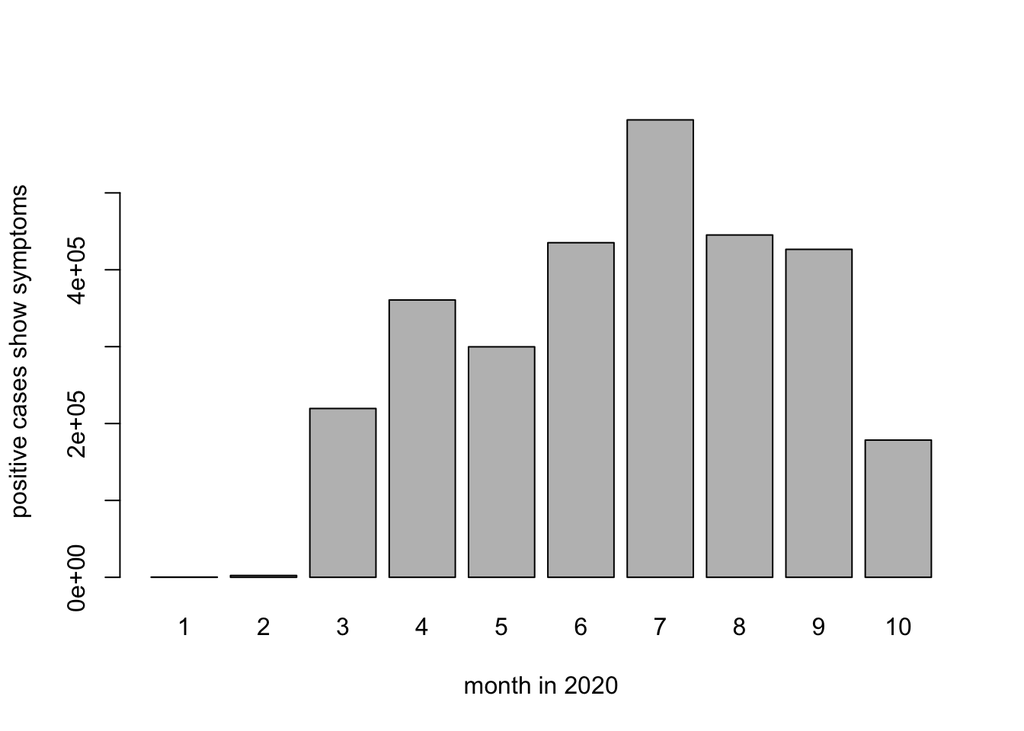

```r
df_positive_test <- df_confirmed[-which(is.na(df_confirmed$pos_spec_dt)),]
df_symptom <- df_confirmed[-which(is.na(df_confirmed$onset_dt)),]

df_positive_test$positive_month <- month(as.POSIXlt(as.character(df_positive_test$pos_spec_dt), format="%Y/%m/%d"))
df_symptom$symptom_month <- month(as.POSIXlt(as.character(df_symptom$onset_dt), format="%Y/%m/%d"))

positive_test = rep(0,10)
symptom = rep(0,10)
for (m in 1:10){
  positive_test[m] = sum(df_positive_test$positive_month==m)
  symptom[m] = sum(df_symptom$symptom_month==m)
}

barplot(symptom,names.arg=1:10, ylab = "positive cases show symptoms", xlab="month in 2020")
```

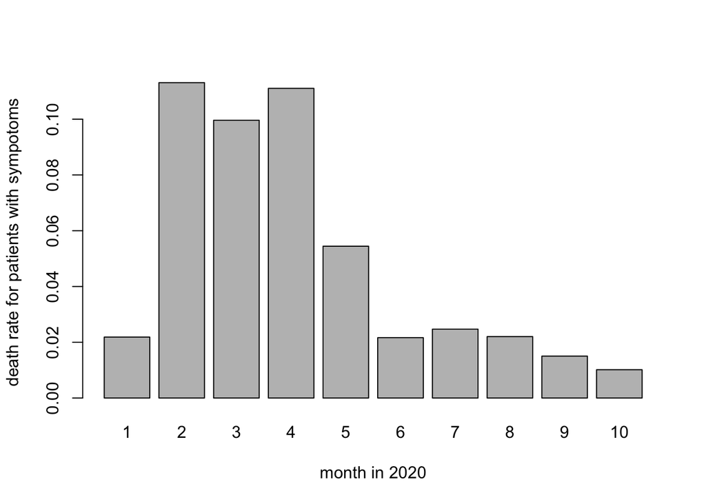

```r
# death rate ~ symptom month
df_symptom = df_symptom[union(which(df_symptom$death_yn=="No"),which(df_symptom$death_yn=="Yes")),]
death_rate = rep(0,10)
for (m in 1:10){
  df_temp = df_symptom[df_symptom$symptom_month==m,]
  death_rate[m] = sum(df_temp$death_yn=="Yes")/dim(df_temp)[1]
}
barplot(death_rate,names.arg=1:10, ylab = "death rate for patients with sympotoms", xlab="month in 2020")
```

```r
df_survival_age_medcond = na.omit(data.frame(df_confirmed$death_yn, df_confirmed$age_group, df_confirmed$medcond_yn))
df_survival_age_medcond[df_survival_age_medcond=="Missing"|df_survival_age_medcond=="Unknown"]<- NA
df_survival_age_medcond = na.omit(df_survival_age_medcond)
head(df_survival_age_medcond)
```

|  | df_confirmed.death_yn | df_confirmed.age_group | df_confirmed.medcond_yn |
| --- | --- | --- | --- |
| 3 | No | 0 - 9 Years | Yes |
| 151 | No | 0 - 9 Years | No |
| 209 | No | 0 - 9 Years | No |
| 224 | No | 0 - 9 Years | No |
| 226 | No | 0 - 9 Years | No |
| 238 | No | 0 - 9 Years | No |

```r
age_range = as.character(unique(df_survival_age_medcond$df_confirmed.age_group))
```

# We can see Feb, March, April, May, these 4 months have much higher death rate.

# Does hospital really help reducing death rate?

```r
# death_yn, age_group, hosp_yn, remove NA, missing and unknown values.

df_hosp = na.omit(data.frame(df_confirmed$death_yn, df_confirmed$age_group, df_confirmed$hosp_yn))
df_hosp[df_hosp=="Missing"|df_hosp=="Unknown"]<- NA
df_hosp = na.omit(df_hosp)
```

# hospitalize vs death rate

# Hospitalize ~ Age, the the older groups have more patients in hospital.

```r
hosp = df_hosp[df_hosp$df_confirmed.hosp_yn=="Yes",]
non_hosp = df_hosp[df_hosp$df_confirmed.hosp_yn=="No",]

# hospitalize vs death rate
sum(hosp$df_confirmed.death_yn =="Yes")/dim(hosp)[1]
```

```
## [1] 0.3193417
```

```r
sum(non_hosp$df_confirmed.death_yn =="Yes")/dim(non_hosp)[1]
```

```
## [1] 0.01146518
```

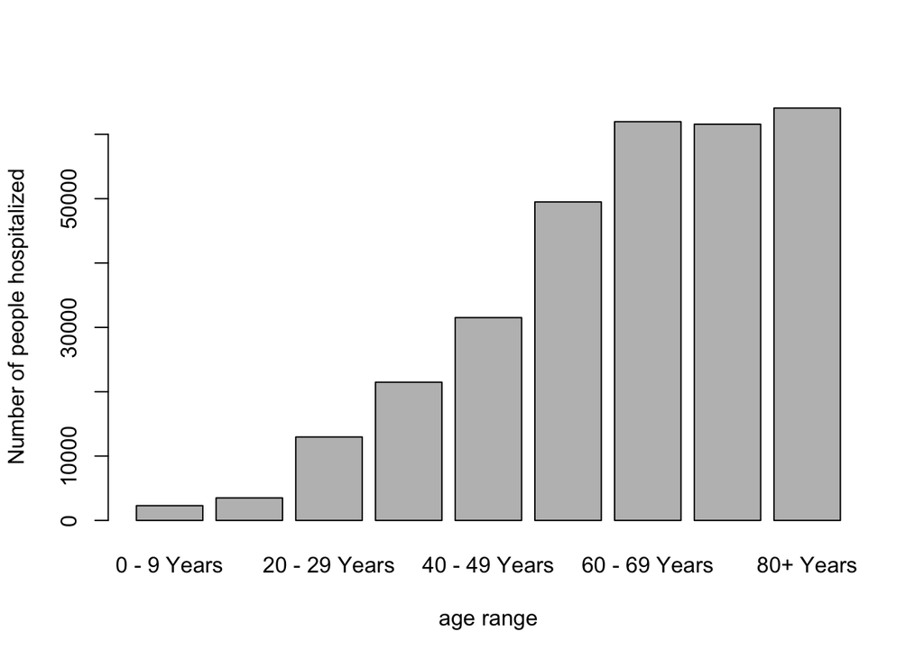

```r
# hospitalized ~ age
hosp_age = rep(0,length(age_range))
# head(hosp)
for (y in 1:length(age_range)){
  hosp_age[y] = dim(hosp[as.character(hosp$df_confirmed.age_group)==age_range[y],])[1]
}
barplot(hosp_age,names.arg=age_range, ylab = "Number of people hospitalized", xlab="age range")
```

# for people hospitalized and not hospitalized, death rate change with respect to age?

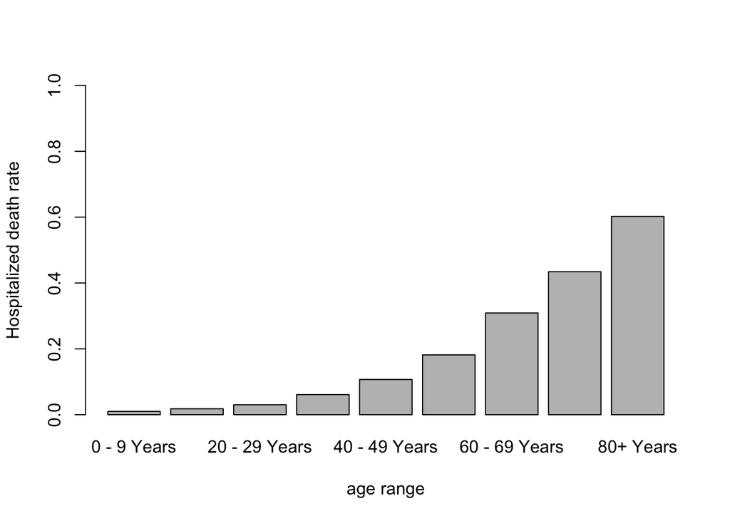

```r
# people hospitalized, death rate in age?
hosp_death_rate = rep(0,length(age_range))
for (y in 1:length(age_range)){
  df_temp = hosp[as.character(hosp$df_confirmed.age_group)==age_range[y],]
  hosp_death_rate[y] = sum(df_temp$df_confirmed.death_yn=="Yes")/dim(df_temp)[1]
}
barplot(hosp_death_rate,names.arg=age_range, ylab = "Hospitalized death rate", xlab="age range", ylim=c(0,1))
```

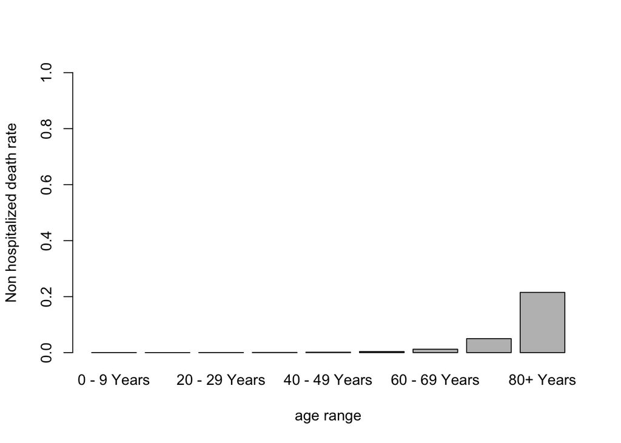

```r
# people not hospitalized, death rate in age?
non_hosp_death_rate = rep(0,length(age_range))
for (y in 1:length(age_range)){
  df_temp = non_hosp[as.character(non_hosp$df_confirmed.age_group)==age_range[y],]
  non_hosp_death_rate[y] = sum(df_temp$df_confirmed.death_yn=="Yes")/dim(df_temp)[1]
}
barplot(non_hosp_death_rate,names.arg=age_range, ylab = "Non hospitalized death rate", xlab="age range", ylim=c(0,1))
```

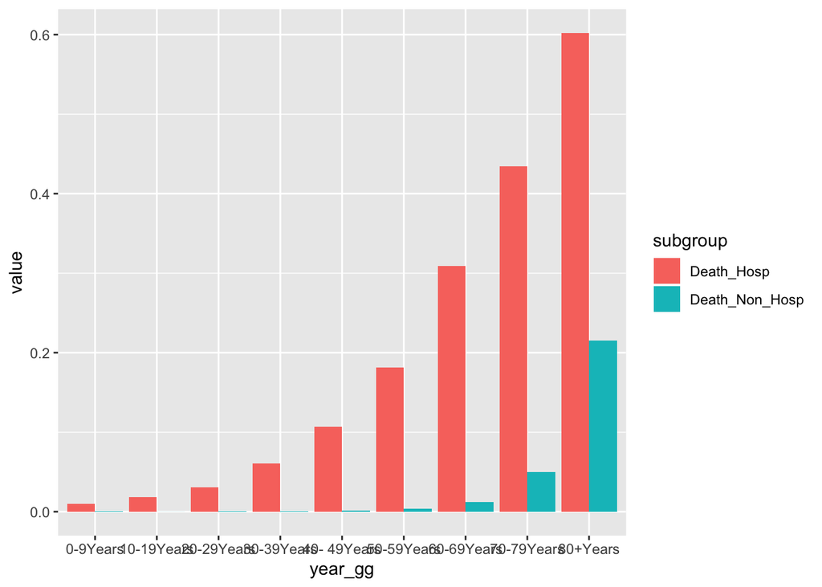

```r
year_gg <- c(rep("0-9Years" , 2) , rep("10-19Years" , 2) , rep("20-29Years" , 2) , rep("30-39Years" , 2),rep("40- 49Years", 2),rep("50-59Years", 2),rep("60-69Years" , 2),rep("70-79Years", 2),rep("80+Years", 2))
subgroup = rep(c("Death_Hosp","Death_Non_Hosp"),9)
value = as.vector(t(cbind(hosp_death_rate, non_hosp_death_rate)))
data_gg <- data.frame(year_gg,subgroup,value)

# Grouped
ggplot(data_gg, aes(fill=subgroup, y=value, x=year_gg)) +
  geom_bar(position="dodge", stat="identity")
```

# people has a lower death rate for not staying in hospital? Why

# for people show symptoms, calculate hospitalized rate vs month change

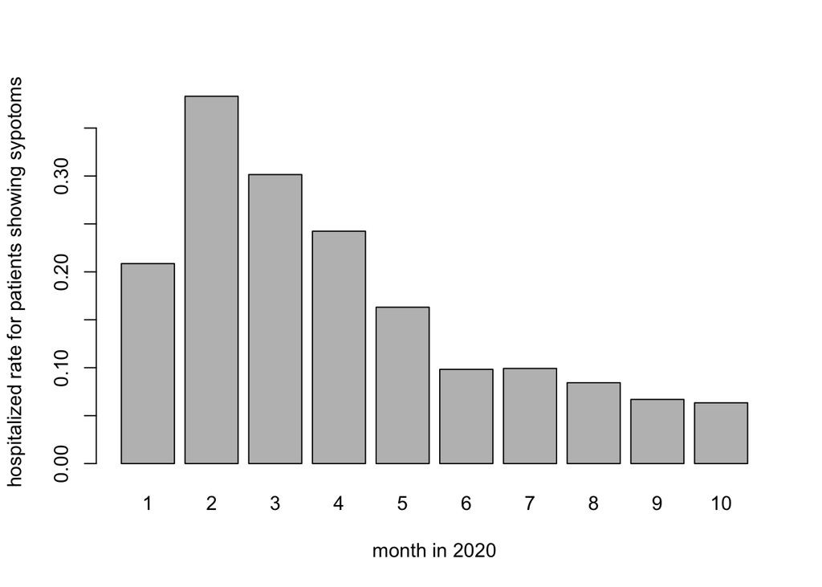

```r
df_month_hosp = na.omit(data.frame(df_symptom$symptom_month, df_symptom$hosp_yn,df_symptom$death_yn))
df_month_hosp[df_month_hosp=="Missing"|df_month_hosp=="Unknown"]<- NA
df_month_hosp = na.omit(df_month_hosp)

symptom_hosp = rep(0,10)
for (m in 1:10){
  df_temp = df_month_hosp[df_month_hosp$df_symptom.symptom_month==m,]
  symptom_hosp[m] = sum(df_temp$df_symptom.hosp_yn=="Yes")/dim(df_temp)[1]
}
barplot(symptom_hosp,names.arg=1:10, ylab = "hospitalized rate for patients showing sypotoms", xlab="month in 2020")
```

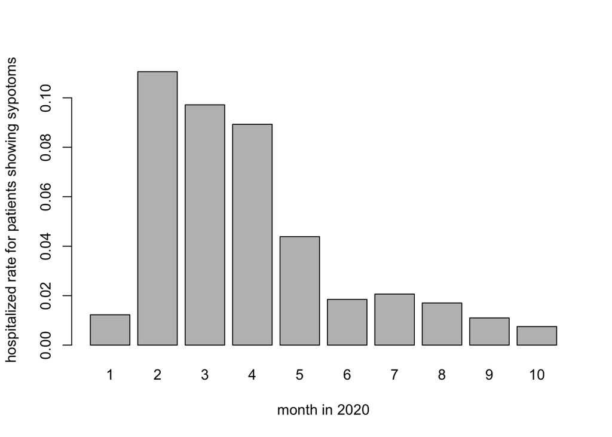

```r
# hospitalized death over month
symptom_death_hosp = rep(0,10)
for (m in 1:10){
  df_temp = df_month_hosp[df_month_hosp$df_symptom.symptom_month==m,]
  symptom_death_hosp[m] = sum(df_temp$df_symptom.hosp_yn=="Yes" & df_temp$df_symptom.death_yn=="Yes")/dim(df_temp)[1]
}
barplot(symptom_death_hosp,names.arg=1:10, ylab = "hospitalized rate for patients showing sypotoms", xlab="month in 2020")
```

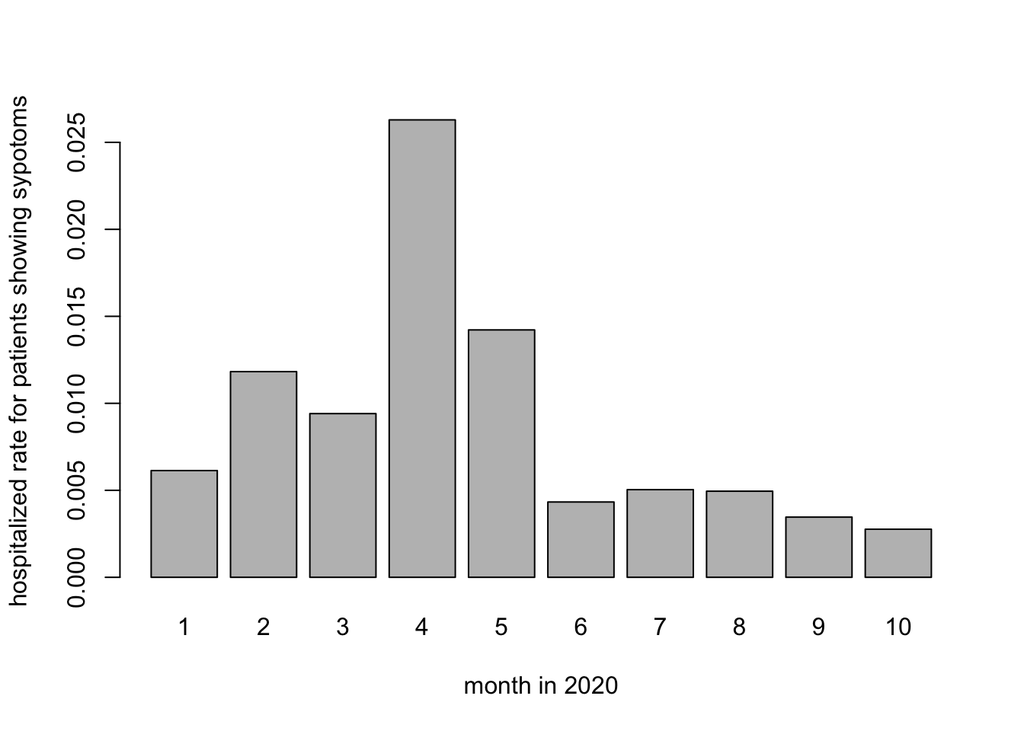

```r
# non-hospitalized death over month
symptom_death_non_hosp = rep(0,10)
for (m in 1:10){
  df_temp = df_month_hosp[df_month_hosp$df_symptom.symptom_month==m,]
  symptom_death_non_hosp[m] = sum(df_temp$df_symptom.hosp_yn=="No" & df_temp$df_symptom.death_yn=="Yes")/dim(df_temp)[1]
}
barplot(symptom_death_non_hosp,names.arg=1:10, ylab = "hospitalized rate for patients showing sypotoms", xlab="month in 2020")
```

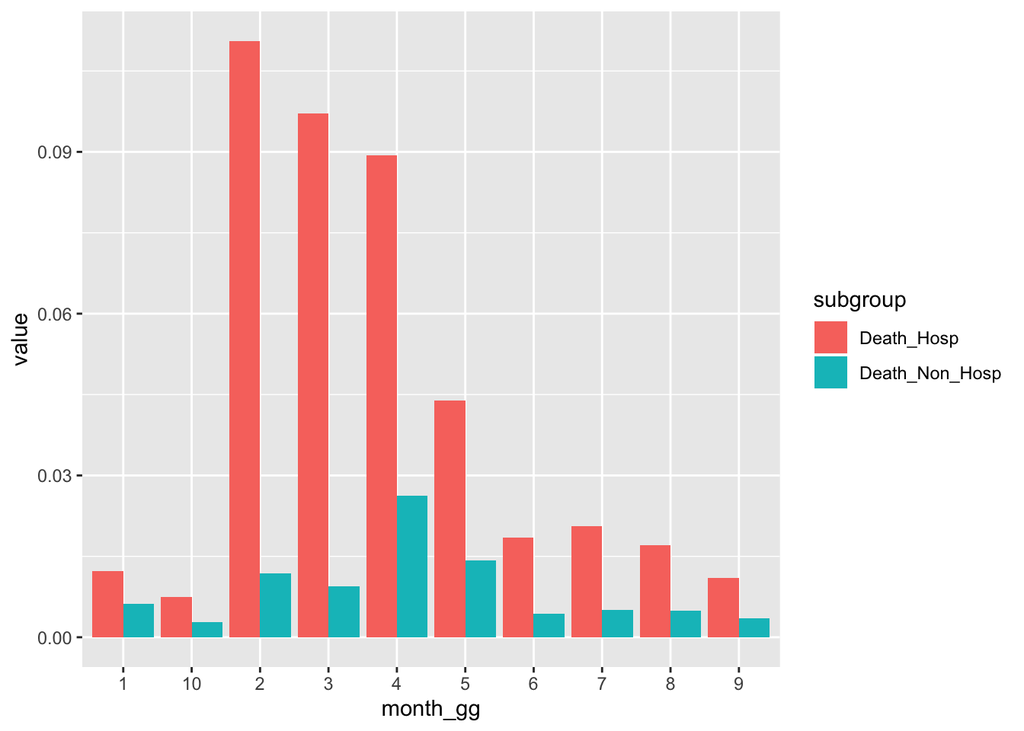

```r
month_gg <- c(rep("1" , 2) , rep("2" , 2) , rep("3" , 2) , rep("4" , 2),rep("5", 2),rep("6", 2),rep("7" , 2),rep("8", 2),rep("9", 2),rep("10", 2))
subgroup = rep(c("Death_Hosp","Death_Non_Hosp"),10)
value = as.vector(t(cbind(symptom_death_hosp, symptom_death_non_hosp)))
data_gg <- data.frame(month_gg,subgroup,value)

# Grouped
ggplot(data_gg, aes(fill=subgroup, y=value, x=month_gg)) +
  geom_bar(position="dodge", stat="identity")
```

# It’s obviously death rate for hospitalized patients are much higher in Feb, March, and April, compared to other month, this is probably due to cross-infections in the hospital at that time, and not enough medical resources.

# Another possibilities could be patients admitted into hospitals are old and have underlying diseases.

# 1) Old people is more likely to die from COVID19

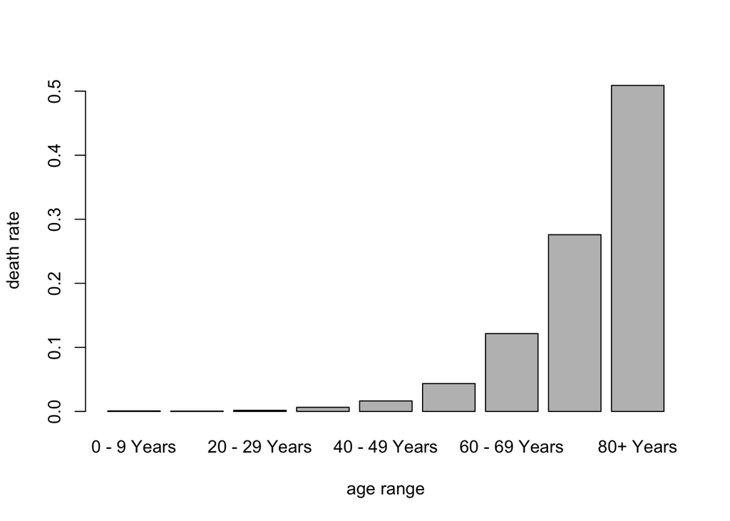

```r
df_survival_age_medcond = na.omit(data.frame(df_confirmed$death_yn, df_confirmed$age_group, df_confirmed$medcond_yn))
df_survival_age_medcond[df_survival_age_medcond=="Missing"|df_survival_age_medcond=="Unknown"]<- NA
df_survival_age_medcond = na.omit(df_survival_age_medcond)
# head(df_survival_age_medcond)
age_range = as.character(unique(df_survival_age_medcond$df_confirmed.age_group))
# typeof(age_range)

# death ~ Age
death_age = rep(0,length(age_range))
for (y in 1:length(age_range)){
  df_temp = df_survival_age_medcond[as.character(df_survival_age_medcond$df_confirmed.age_group)==age_range[y],]
  death_age[y] = sum(df_temp$df_confirmed.death_yn=="Yes")/dim(df_temp)[1]
}
barplot(death_age,names.arg=age_range, ylab = "death rate", xlab="age range")
```

# death rate vs underlying disease condition

```r
df_medcond = df_survival_age_medcond[df_survival_age_medcond$df_confirmed.medcond_yn=="Yes",]
df_non_medcond= df_survival_age_medcond[df_survival_age_medcond$df_confirmed.medcond_yn=="No",]
sum(df_medcond$df_confirmed.death_yn=="Yes")/dim(df_medcond)[1]
```

```
## [1] 0.1479559
```

```r
sum(df_non_medcond$df_confirmed.death_yn=="Yes")/dim(df_non_medcond)[1]
```

```
## [1] 0.007141119
```

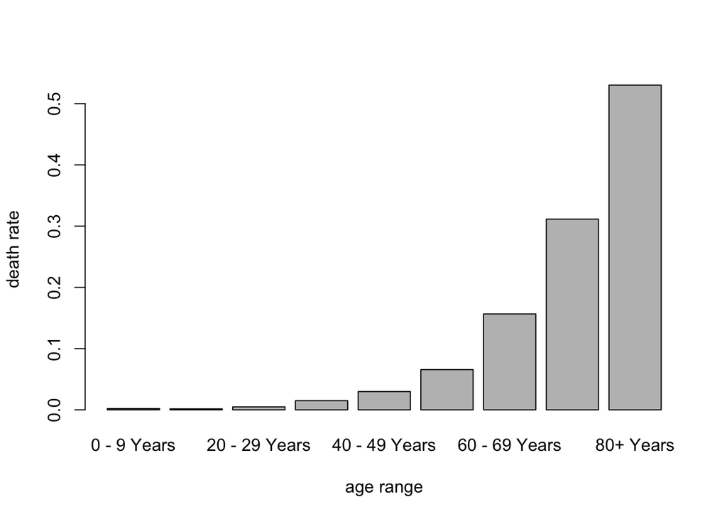

```r
# death vs age for those with medical condition

death_medcond_age = rep(0,length(age_range))
for (y in 1:length(age_range)){
  df_temp = df_medcond[as.character(df_medcond$df_confirmed.age_group)==age_range[y],]
  death_medcond_age[y] = sum(df_temp$df_confirmed.death_yn=="Yes")/dim(df_temp)[1]
}
barplot(death_medcond_age,names.arg=age_range, ylab = "death rate", xlab="age range")
```

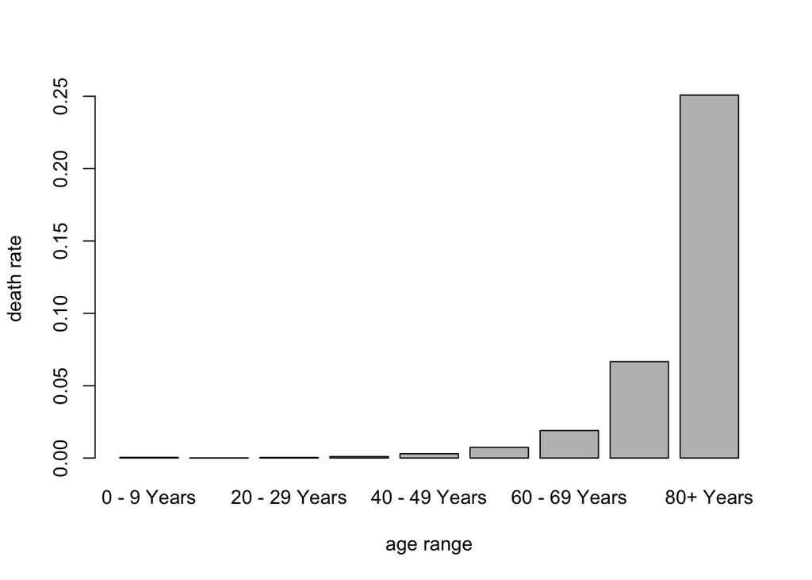

```r
# death vs age for those without medical condition
death_non_medcond_age = rep(0,length(age_range))
for (y in 1:length(age_range)){
  df_temp = df_non_medcond[as.character(df_non_medcond$df_confirmed.age_group)==age_range[y],]
  death_non_medcond_age[y] = sum(df_temp$df_confirmed.death_yn=="Yes")/dim(df_temp)[1]
}
barplot(death_non_medcond_age,names.arg=age_range, ylab = "death rate", xlab="age range")
```

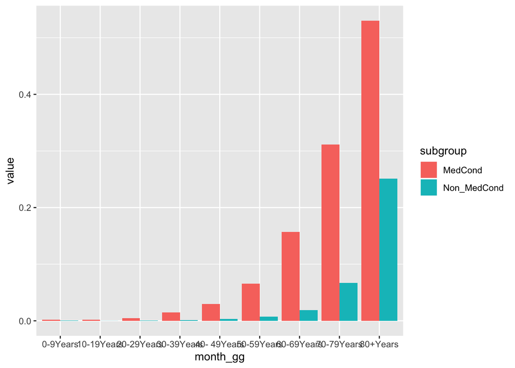

```r
# ggplot
month_gg <- c(rep("0-9Years" , 2) , rep("10-19Years" , 2) , rep("20-29Years" , 2) , rep("30-39Years" , 2),rep("40- 49Years", 2),rep("50-59Years", 2),rep("60-69Years" , 2),rep("70-79Years", 2),rep("80+Years", 2))
subgroup = rep(c("MedCond","Non_MedCond"),9)
value = as.vector(t(cbind(death_medcond_age, death_non_medcond_age)))
data_gg <- data.frame(month_gg,subgroup,value)

# Grouped
ggplot(data_gg, aes(fill=subgroup, y=value, x=month_gg)) +
  geom_bar(position="dodge", stat="identity")
```

# It shows people with medical conditions have much higher chance of passing away in the pademic, especially for those mid-aged to senior aged.

# And old people have higher ratio in having medical conditions among to their peers.

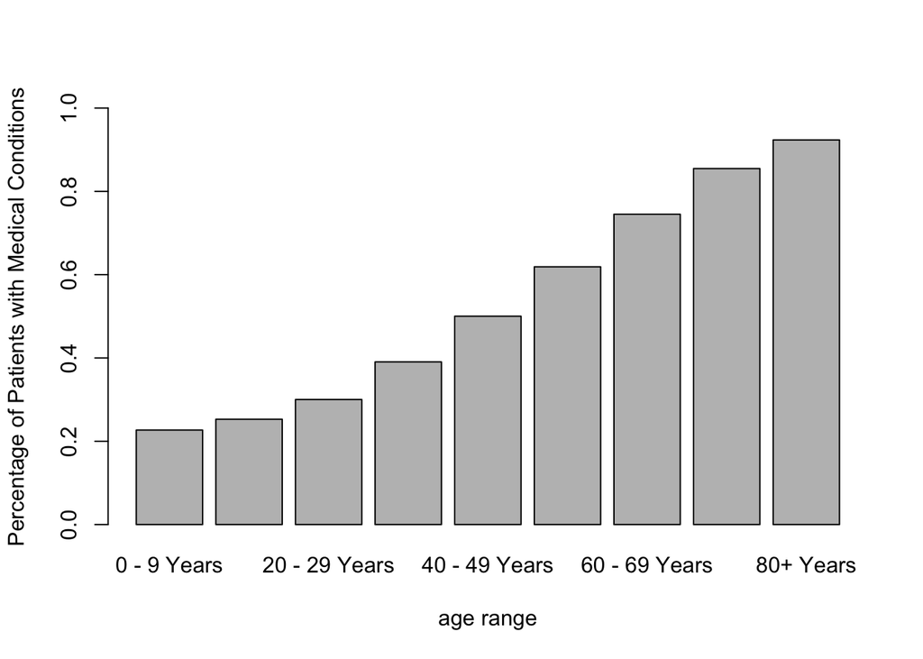

```r
medcond_rate = rep(0,length(age_range))
for (y in 1:length(age_range)){
  df_temp = df_survival_age_medcond[as.character(df_survival_age_medcond$df_confirmed.age_group)==age_range[y],]
  medcond_rate[y] = sum(df_temp$df_confirmed.medcond_yn=="Yes")/dim(df_temp)[1]
}
barplot(medcond_rate,names.arg=age_range, ylab = "Percentage of Patients with Medical Conditions", xlab="age range", ylim=c(0,1))
```

# Does pre-screening help reducing the death rate. (Pre-screening is defined as test positive before showing symptoms)

```r
# Positive before symptom VS after symptom ~ survival rate
df_complete_time <- df_confirmed[-union(which(is.na(df_confirmed$pos_spec_dt)),which(is.na(df_confirmed$onset_dt))),]

date_diff = as.Date(as.character(df_complete_time$onset_dt),format="%Y/%m/%d") - as.Date(as.character(df_complete_time$pos_spec_dt),format="%Y/%m/%d")
df_complete_time$date_diff = date_diff

df_complete_time = na.omit(data.frame(df_complete_time$death_yn, df_complete_time$age_group, df_complete_time$medcond_yn,df_complete_time$date_diff))
df_complete_time[df_complete_time=="Missing"|df_complete_time=="Unknown"]<- NA
df_complete_time = na.omit(df_complete_time)

pre_screening = df_complete_time[df_complete_time$df_complete_time.date_diff<0,]
symptom_show = df_complete_time[df_complete_time$df_complete_time.date_diff>=0,]

# screening vs death rate
sum(pre_screening$df_complete_time.death_yn=="Yes")/dim(pre_screening)[1]
```

```
## [1] 0.03232202
```

```r
sum(symptom_show$df_complete_time.death_yn=="Yes")/dim(symptom_show)[1]
```

```
## [1] 0.07047638
```

# It shows pre-screening can lower the death rate from 7% to 3%.

# Let’s see which age group does the most screening

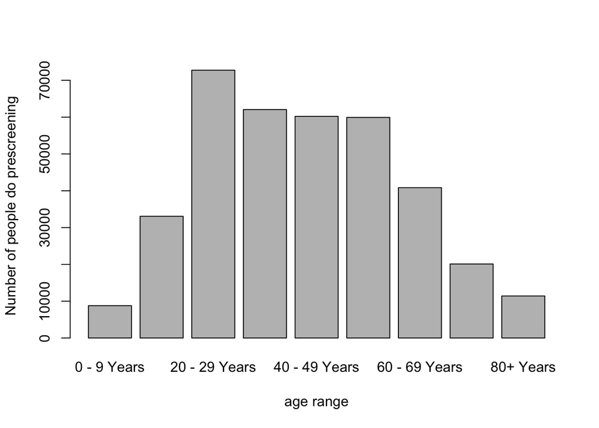

```r
# pre-screening rate ~ age
pre_screening_age = rep(0,length(age_range))
# head(pre_screening)
for (y in 1:length(age_range)){
  pre_screening_age[y] = dim(pre_screening[as.character(pre_screening$df_complete_time.age_group)==age_range[y],])[1]
}
barplot(pre_screening_age,names.arg=age_range, ylab = "Number of people do prescreening", xlab="age range")
```